# PD2 - Raport

Michał Klein

2023-03-22

## Oryginalny wykres

Oryginalny wykres był pokazywany bezpośrednio w wiadomościach TVP. Miał on przedstawiać dysproporcję w oglądalności między stacjami TVP a innymi. Na pierwszy rzut oka różnica wydaje się kolosalna, jednak przy dokładniejszej analizie wykresu, a dokładniej osi y, można zauważyć, że skala wcale nie zaczyna się od 0. Powoduje to, że mimo tego, że różnica jest niewielka, to sprawia wrażenie ponad dwukrotnej przy tak sprytnie dobranej skali.

[figure not shown]

źródło: https://wiadomosci.tvp.pl/68490132/widzowie-wybieraja-telewizje-polska

## Te same dane, lepszy wykres

Poniżej zająłem się lekkimi poprawkami w wyżej pokazanym wykresie. Wykres ten ma jeden znaczący problem. Jest nim to, że skala jest tak dobrana, żeby zmylić odbiorcę. Przez to, że oś y nie zaczyna się od zera, to drobne różnice sprawiają na podanym wykresie wrażenie kolosalnych. Przeskalowanie wykresu powinno załagodzić ten problem. Udogodnieniem dla odbiorcy również byłaby możliwość odczytania dokładnych wartości. Nie da się odczytać ich z pierwotnego wykresu bez dokładnego przyglądania się, przy czym pamiętajmy, że wykres ten został stworzony w celu pokazywania go w telewizji, gdzie przy ciągle przemijających obrazach nie ma czasu na dokładniejszą analizę tego, co się widzi. Tak więc poniżej można zauważyć poprawiony wykres, w którym rozwiązuję wyżej wspomniane problemy.

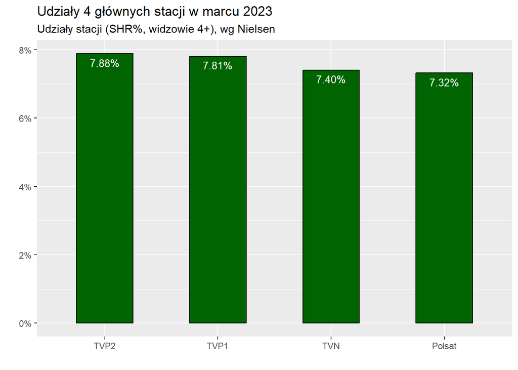

```r
stacje <- c("TVP2","TVP1","TVN","Polsat")
wyniki <- c(0.0788, 0.0781, 0.0740, 0.0732)
df <- data.frame(stacje, wyniki)

plot <- ggplot(df, aes(x = fct_inorder(stacje), y = wyniki)) +
  geom_bar(stat="identity", width = 0.5, color = "black", fill = "darkgreen") +
  geom_text(aes(label = c("7.88%", "7.81%", "7.40%", "7.32%")), vjust = 1.6, color = "white", size = 3.5) +
  scale_y_continuous(labels=scales::percent) +
  labs(title = "Udziały 4 głównych stacji w marcu 2023",
       subtitle = "Udziały stacji (SHR%, widzowie 4+), wg Nielsen",
       x = "",
       y = "")

plot
```

## Dlaczego ten wykres jest lepszy?

Zarówno pierwszy, jak i drugi wykres, obrazują te same dane. Dlaczego więc tak bardzo się od siebie różnią? Który z nich lepiej przedstawia te dane? Jak już wyżej wspomniałem, pierwszy wykres przedstawia dane tak, żeby zmylić odbiorcę. Drugi przedstawia te same dane “czarno na białym”. Dla uważnego odbiorcy, oba wykresy dostarczą interesujące go dane, jednak osobę, która tylko szybko rzuci okiem na wykres, pierwszy może łatwo zmylić. Drugi wykres jest czytelny od razu, nie ma w nim żadnych “sztuczek”. Można jasno z niego odczytać, że różnica w oglądalności poszczególnych stacji jest niewielka, przy czym pierwszy wykres wprowadza nas wizualnie w błąd, że owa różnica jest ogromna. Podsumowując, drugi wykres rzetelniej przedstawia te same dane, niż pierwszy, spełniając więcej standardów poprawnego wykresu, i nie próbując wprowadzać odbiorcy w błąd, co czyni go lepszym.